# Chap5.3-5.4

Mijeong Kim

```r
library(tsibble)
library(tsibbledata)
library(tibble)
library(dplyr)
library(knitr)
library(ggplot2)
library(fpp3)
library(fpp2)
library(seasonal)
library(feasts)
```

## 5.3 Fitted values and residuals

### Fitted values

시계열 데이터에서 각 관측치는 이전 모든 관측값을 사용하여 예측될 수 있으며, 이를 **적합값(fitted values)**이라고 한다. 적합값은 보통 한 단계 예측(one-step forecasts)을 의미하며, 다음과 같이 표기된다.

$$\hat{y}_{t|t-1}$$

일반적으로 간략하게 $\hat{y}_t$라고 쓰기도 한다.

#### 적합값과 실제 예측의 차이

적합값은 종종 **진짜 예측값(true forecasts)**이 아닐 수도 있다. 이는 예측 모델의 매개변수가 전체 데이터(미래 값 포함)를 사용하여 추정되기 때문이다.

- **평균(mean) 방법**: 적합값은 전체 데이터의 평균으로 설정됨
  $$\hat{y}_t = \hat{c}$$
  여기서 $\hat{c}$는 모든 시점의 데이터를 포함한 평균값이다.
- **드리프트(drift) 방법**: 드리프트 매개변수는 전체 데이터를 사용하여 추정됨
  $$\hat{y}_t = y_{t-1} + \hat{c}$$
  여기서,
  $$\hat{c} = \frac{y_T - y_1}{T-1}$$

  “hat”이 붙은 $\hat{c}$는 추정된 값이라는 것을 의미한다.

### Residuals

시계열 모델에서 **잔차(residuals)**는 모델을 적합한 후 남아있는 오차를 의미하며, 관측값과 적합값의 차이로 정의된다.

$$e_t = y_t - \hat{y}_t$$

#### 변환이 적용된 경우: 혁신 잔차(Innovation Residuals)

모델에서 변환(transformation)이 사용된 경우, 변환된 척도에서 잔차를 분석하는 것이 유용하다. 이를 **혁신 잔차(innovation residuals)**라고 한다.

예를 들어, 데이터의 로그 변환이 적용되었다면:

$$w_t = \log(y_t)$$

이때,

- **혁신 잔차**: $w_t - \hat{w}_t$
- **일반 잔차**: $y_t - \hat{y}_t$

변환이 적용되지 않은 경우, 혁신 잔차와 일반 잔차는 동일하므로 단순히 **잔차(residuals)**라고 부른다.

#### 적합값과 잔차 계산

적합값과 잔차는 `augment()` 함수를 사용하여 얻을 수 있다. 예를 들어, 5.2절의 맥주 생산 데이터 예제에서 적합 모델을 `beer_fit`으로 저장했다면, 다음과 같이 `augment()` 함수를 적용할 수 있다.

```r
train <- aus_production |>
  filter_index("1992 Q1" ~ "2006 Q4")
# Fit the models
beer_fit <- train |>
  model(
    Mean = MEAN(Beer),
    `Naïve` = NAIVE(Beer),
    `Seasonal naïve` = SNAIVE(Beer)
  )
augment(beer_fit)
```

```
## # A tsibble: 180 x 6 [1Q]
## # Key:       .model [3]
##    .model Quarter  Beer .fitted .resid .innov
##    <chr>    <qtr> <dbl>   <dbl>  <dbl>  <dbl>
##  1 Mean   1992 Q1   443    436.   6.55   6.55
##  2 Mean   1992 Q2   410    436. -26.4  -26.4
##  3 Mean   1992 Q3   420    436. -16.4  -16.4
##  4 Mean   1992 Q4   532    436.  95.6   95.6
##  5 Mean   1993 Q1   433    436.  -3.45  -3.45
##  6 Mean   1993 Q2   421    436. -15.4  -15.4
##  7 Mean   1993 Q3   410    436. -26.4  -26.4
##  8 Mean   1993 Q4   512    436.  75.6   75.6
##  9 Mean   1994 Q1   449    436.  12.6   12.6
## 10 Mean   1994 Q2   381    436. -55.4  -55.4
## # ℹ 170 more rows
```

`augment()` 함수를 사용하면 원본 데이터에 세 개의 새로운 열이 추가된다.

- `.fitted`: 적합값(fitted values)
- `.resid`: 잔차(residuals)
- `.innov`: 혁신 잔차(innovation residuals)
  - 변환이 적용되지 않은 경우, 혁신 잔차는 일반 잔차와 동일함

## 5.4 Residual diagnostics

좋은 예측 방법은 **혁신 잔차(innovation residuals)**가 다음과 같은 성질을 가져야 한다.

1. **비상관성(uncorrelated)**
   - 혁신 잔차 간에 상관관계가 없어야 함
   - 상관관계가 있다면, 잔차에 남아 있는 정보를 활용하여 예측을 개선할 수 있음
2. **평균이 0(zero mean)**
   - 잔차의 평균이 0이 아니라면, 예측이 편향(biased)됨
   - 잔차의 평균이 $m$이면, 모든 예측값에 $m$을 더하여 편향 문제를 해결 가능

이 두 가지 조건을 충족하지 못하면 예측 방법을 개선할 수 있다.  
그러나, 이 조건을 만족한다고 해서 반드시 최적의 예측 방법이라고 할 수는 없음.

#### 추가적으로 유용한 성질

다음 두 가지 성질이 있으면 예측 신뢰구간 계산이 쉬워짐(그러나 필수는 아님).

1. **분산이 일정함(constant variance, homoscedasticity)**
2. **정규 분포(normal distribution)를 따름**

이 두 조건을 만족하지 않는다고 해서 반드시 모델을 개선할 필요는 없음.  
Box-Cox 변환이 도움이 될 수 있지만, 보통 다른 방식으로 신뢰구간을 계산해야 함.  
(비정규 혁신 잔차 처리 방법은 5.5절에서 설명)

### Example: Forecasting Google daily closing stock prices

5.2절에서 다룬 **Google의 일일 종가 예제**를 계속 분석한다.  
주식 시장 가격과 지수에서는 **나이브(naïve) 방법**이 종종 최적의 예측 방법이다.

- 각 예측값은 마지막 관측값과 동일하다.

  $$\hat{y}_t = y_{t-1}$$
- 따라서, 잔차(residuals)는 연속된 관측값 간의 차이와 같다.

  $$e_t = y_t - \hat{y}_t = y_t - y_{t-1}$$

#### 2015년 Google 주가 그래프

아래 그래프는 **2015년 거래일 기준 Google의 일일 종가**를 나타낸다.  
특히 **2015년 7월 17일**, 예상보다 강한 2분기 실적 발표로 인해 **주가가 16% 급등**한 것이 보인다.  
(데이터는 5.2절에서 생성된 `google_2015` 객체를 사용함.)

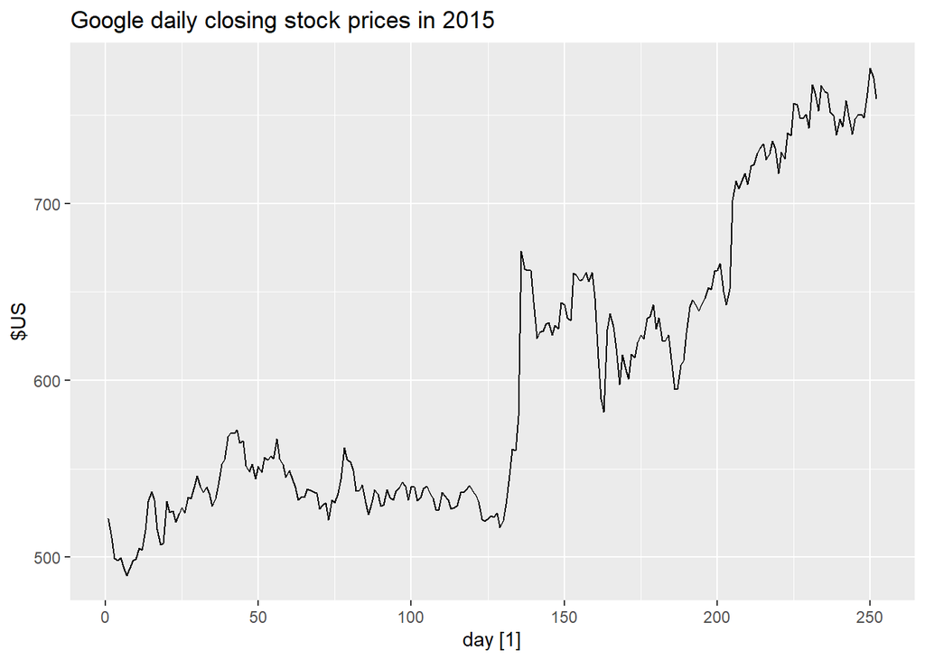

```r
google_stock <- gafa_stock |>
  filter(Symbol == "GOOG", year(Date) >= 2015) |>
  mutate(day = row_number()) |>
  update_tsibble(index = day, regular = TRUE)
# Filter the year of interest
google_2015 <- google_stock |> filter(year(Date) == 2015)

autoplot(google_2015, Close) +
  labs(y = "$US",
       title = "Google daily closing stock prices in 2015")
```

naïve 방법을 사용하여 이 시계를 예측한 후 얻은 잔차(residuals)는 그림 5.10에 나타나 있다. 7월의 예상치 못한 주가 급등으로 인해 큰 양의 잔차가 발생하였다.

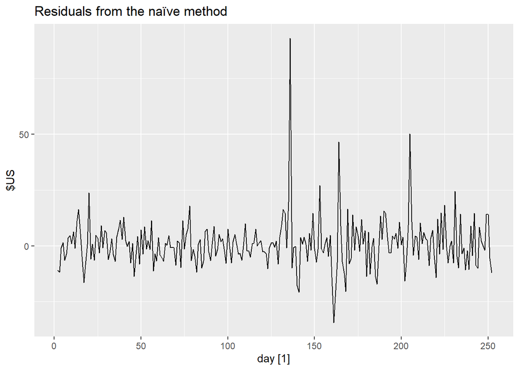

```r
aug <- google_2015 |>
  model(NAIVE(Close)) |>
  augment()
autoplot(aug, .innov) +
  labs(y = "$US",
       title = "Residuals from the naïve method")
```

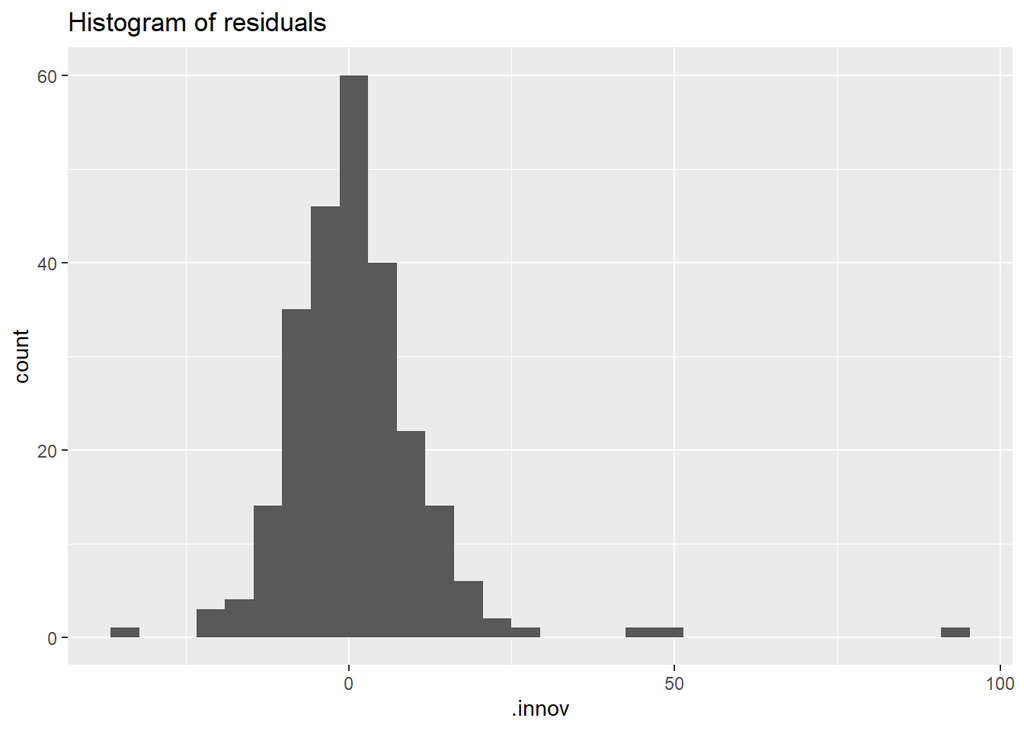

```r
aug |>
  ggplot(aes(x = .innov)) +
  geom_histogram() +
  labs(title = "Histogram of residuals")
```

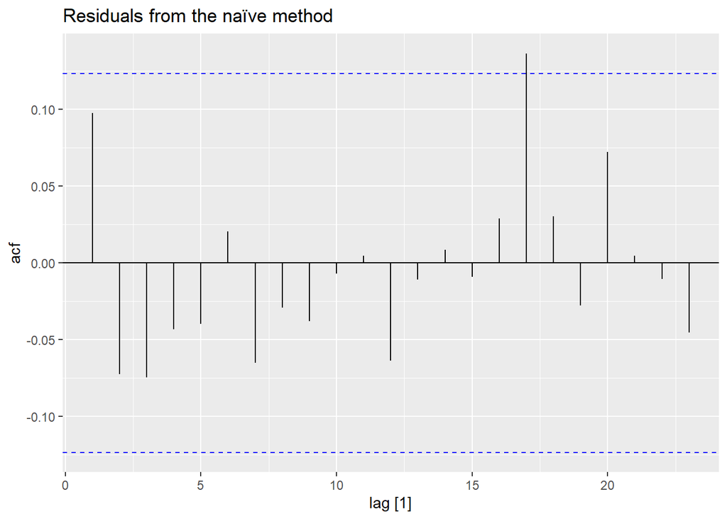

```r
aug |>
  ACF(.innov) |>
  autoplot() +
  labs(title = "Residuals from the naïve method")
```

#### 잔차 분석 결과

- **예측 성능 평가**
  - 잔차의 평균이 **0에 가까움** → **예측에 편향이 없음**
  - 잔차 시계열에 **유의미한 상관관계 없음** → **추가 정보가 남아있지 않음**
  - 잔차의 변동성이 일정함(한 개의 이상값 제외) → **분산이 일정하다고 간주 가능**
- **잔차의 분포 분석**
  - 히스토그램에서 **오른쪽 꼬리가 약간 길어 보임** → **정규성을 따르지 않을 가능성 있음**
  - 정규분포를 가정한 신뢰구간 계산이 부정확할 수 있음

#### 잔차 분석 그래프 생성

잔차 분석을 위한 편리한 함수인 `gg_tsresiduals()`를 사용하여 다음과 같은 그래프를 생성할 수 있음.

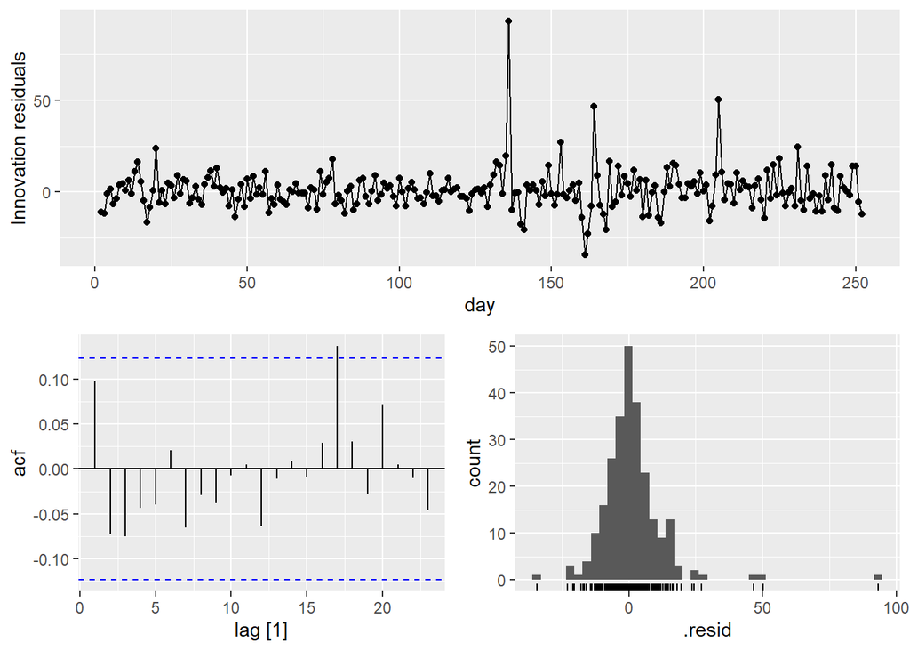

```r
google_2015 |>
  model(NAIVE(Close)) |>
  gg_tsresiduals()
```

### Portmanteau tests for autocorrelation

잔차의 자기상관을 평가하기 위해 **ACF(자기상관 함수) 플롯**을 확인할 수 있다.  
그러나 이는 개별적인 시차(lag) 값을 독립적으로 검정하는 것이므로, **오차의 누적 효과**를 파악하기 어렵다.

이를 해결하기 위해, **첫 $\ell$개의 자기상관 값이 백색 잡음(white noise) 과정에서 기대되는 값과 유의미하게 다른지 검정하는 방법**이 필요하다.  
이를 **포르망토 검정(Portmanteau Test)**이라 하며, 대표적인 방법으로 **Box-Pierce 검정**과 **Ljung-Box 검정**이 있다.

#### 1. Box-Pierce 검정

Box-Pierce 통계량은 다음과 같이 정의된다.

$$Q = T \sum_{k=1}^{\ell} r_k^2$$

- $\ell$ = 고려하는 최대 시차(lag)
- $T$ = 전체 관측값 수
- $r_k$ = 시차 $k$에서의 자기상관 값

값이 클수록 잔차가 백색 잡음에서 벗어날 가능성이 높다.

- **비계절(non-seasonal) 데이터**: $\ell = 10$ 추천
- **계절적(seasonal) 데이터**: $\ell = 2m$ 추천 (단, $m$은 계절 주기)
- 단, $\ell$ 값이 너무 크면 검정이 부정확해질 수 있으므로, $\ell > T/5$인 경우 $\ell = T/5$ 사용

#### 2. Ljung-Box 검정

Ljung-Box 검정은 Box-Pierce 검정보다 정확도가 높은 방법이며, 다음과 같이 정의된다.

$$Q^* = T(T+2) \sum_{k=1}^{\ell} \frac{r_k^2}{T-k}$$

- **$Q^*$ 값이 클수록** 잔차가 백색 잡음일 가능성이 낮음
- **$Q$ 및 $Q^*$는 자유도 $\ell$을 가진 $\chi^2$ 분포를 따름**
  - 따라서 $Q$나 $Q^*$ 값이 임계값보다 크면, 잔차가 백색 잡음이 아님을 의미

```r
aug |> features(.innov, box_pierce, lag = 10)
```

```
## # A tibble: 1 × 4
##   Symbol .model       bp_stat bp_pvalue
##   <chr>  <chr>          <dbl>     <dbl>
## 1 GOOG   NAIVE(Close)    7.74     0.654
```

#### 대체 예측 방법: 드리프트(Drift) 방법

- Google 일일 종가 예측에 적합할 수 있음
- tidy() 함수를 사용하면 **드리프트 계수(drift coefficient)**를 확인 가능
- 드리프트 계수는 과거 데이터에서 관측된 평균 일일 변동량을 측정함

```r
fit <- google_2015 |> model(RW(Close ~ drift()))
tidy(fit)
```

```
## # A tibble: 1 × 7
##   Symbol .model              term  estimate std.error statistic p.value
##   <chr>  <chr>               <chr>    <dbl>     <dbl>     <dbl>   <dbl>
## 1 GOOG   RW(Close ~ drift()) b        0.944     0.705      1.34   0.182
```

Ljung-Box 검정을 적용한 결과는 다음과 같다.

```r
augment(fit) |> features(.innov, ljung_box, lag=10)
```

```
## # A tibble: 1 × 4
##   Symbol .model              lb_stat lb_pvalue
##   <chr>  <chr>                 <dbl>     <dbl>
## 1 GOOG   RW(Close ~ drift())    7.91     0.637
```

naïve 방법과 마찬가지로, 드리프트(drift) 방법의 잔차도 백색 잡음(white noise) 시계열과 구별되지 않는다.

9장과 10장에서 다루는 ARIMA 모델의 경우, 더 나은 결과를 얻기 위해 자유도를 조정한다.